# WGCNA and Gene Ontology Enrichment analysis

[Canales et al. 2020 (under review): A temporal map of maternal immune activation-induced changes reveals a shift in neurodevelopmentiming and perturbed cortical development in mice](https://www.biorxiv.org/content/10.1101/2020.06.13.150359v1)

Data analysis by: Karol Cichewicz, kcichewicz@ucdavis.edu Alexander Nord, asnord@ucdavis.edu, [Lab website](https://nordlab.faculty.ucdavis.edu/) Raw data available at GSE166376

Abstract

**Background** Environmental insults that activate the maternal immune system are potent primers of developmental neuropathology and maternal immune activation (MIA) has emerged as a risk factor for neurodevelopmental and psychiatric disorders. Animal models of MIA provide an opportunity to identify molecular pathways that initiate disease processes and lead to neuropathology and behavioral deficits in offspring. MIA-induced behaviors are accompanied by anatomical and neurochemical alterations in adult offspring that parallel those seen in affected human populations.

**Methods** We performed transcriptional profiling and neuroanatomical characterization in a time course across mouse embryonic cortical development, following MIA via single injection of the viral mimic polyinosinic:polycytidylic acid (polyI:C) at E12.5. Transcriptional changes identified in the cortex of MIA offspring at E17.5 were validated and mapped to cortical neuroanatomy and cell types via protein analysis and immunohistochemistry.

**Results** MIA induced strong transcriptomic signatures, including induction of genes associated with hypoxia, immune signaling, and angiogenesis. The acute response identified 6h after the MIA insult was followed by changes in proliferation, neuronal and glial differentiation, and cortical lamination that emerged at E14.5 and peaked at E17.5. Decreased numbers of proliferative cell types in germinal zones and alterations in neuronal and glial cell types across cortical lamina were identified in the MIA-exposed cortex.

**Conclusions** MIA-induced transcriptomic signatures in fetal offspring overlap significantly with perturbations identified in neurodevelopmental disorders (NDDs), and provide novel insights into alterations in molecular and developmental timing processes linking MIA and neuropathology, potentially revealing new targets for development of novel approaches for earlier diagnosis and treatment of these disorders.

```r
# Directory structure
github_dir <- file.path("G:/Shared drives/Nord Lab - Computational Projects/MIA/Canales_eLIFE_2021_WGCNA_GO")

# This directory is available in the repository dedicated to differential expression
extsub_dir <- file.path("G:/Shared drives/Nord Lab - Computational Projects/MIA/Canales_et_al_eLIFE_DE_repo/Canales_eLIFE_2021_DE/Extra_submission files")


setwd(github_dir)


# Global R markdown code chunk options
knitr::opts_chunk$set(message=FALSE,
                      warning = FALSE,
                      error=FALSE,
                      echo=TRUE,
                      cache=FALSE,
                      fig.width = 7, fig.height = 6,
                      fig.align = 'left')

# R packages
library(sva)
library(RUVnormalize)
library(pheatmap)
library(edgeR)
library(GenomicFeatures)
library(mclust)
library(parallel)
library(ggplot2)
library(reshape2)
library(dplyr)
library(data.table)
library(DT)
library(RColorBrewer)
library(knitr)
library(ggrepel)
library(gridExtra)
library(grid)
library(plyr)
library(plotly)
library(Hmisc)
library(WGCNA)
library(knitr)
```

```r
# Loads environment objects from the DE analysis.
#load("G:/Shared drives/Nord Lab - Computational #Projects/MIA/Canales_et_al_eLIFE_DE_repo/Canales_eLIFE_2021_DE/Canales_2021_eLIFE_DE_workspace.RData")
```

# 1. WGCNA

WGCNA approach run on a full rpkm data set consisting of 24015 genes. Genes with low expression are excluded from the analysis after the network construction, limiting the gene set to 17195.

```r
# Note: Some of the comments were copied/pasted from WGCNA documentation.

# Reads Gene counts, 24015 genes x 74 samples
exp.original <- read.csv(paste0(extsub_dir,"/", "Gene_counts.csv"))
rownames(exp.original) <- exp.original$X
exp.original$X <- NULL

# Reading metadata
sample.info <- read.csv(paste0(extsub_dir,"/", "metadata.csv"))

options(stringsAsFactors = FALSE)
#allowWGCNAThreads()  # Multi-threading within compiled code is not available on Windows

# Gene lengths calculation
load(paste0(extsub_dir,"/","exonic.gene.sizes"))

gene.lengths <- as.numeric(lapply(1:nrow(exp.original), function(x) FUN= as.numeric(exonic.gene.sizes[rownames(exp.original)[x]])))

# Calculating differences in rpkm values
rpkm.data <- rpkm(exp.original, gene.length=gene.lengths, log=T, prior.count=0.25)

# Note: There is a minor discrepancy between the rpkm values calculated above, and the values calculated and used during the development phase of this WGCNA analysis. On average, gene rpkm values differ by 0.0004538474, with a range of 1.312417e-09 to 1.632966e-03. These are biologically negligible differences, but they interfere with the reproducibility of some of the plots presented in the manuscript. In order to maintain reproducibility the object rpkm.data_old.RData is loaded from the harddrive. Column names used during the development phase of the project are translated to the current format using the dict data frame. Update from R3.x.x to R 4.0.2, or an update of the edgeR::rpkm() function, resulting in a change in how floating point numbers are handled, is the most likely reason of issue.

load("rpkm.data_old.RData")

dict <- read.csv("sample_dict.csv")
dict$X <- NULL

# This sapply function calculates differences between two rpkm() results.
# It's commented out as a not critical part of this report
#rpkm_new_old_diffs <- sapply(1:24015, function(x){

#df1 <- as.data.frame(reshape2::melt(rpkm.data[x,]))
#df1 <- data.frame("sample_new" = rownames(df1), "value" = df1$value)

#df2 <- reshape2::melt(rpkm.data_old[x,])
#df2 <- data.frame("sample_old" = paste0("X", rownames(df2)), "value" = df2$value)
#df2 <- merge(df2, dict, by.x = "sample_old", by.y = "sample_old")[,c(3,2)]

#diff_df <- merge(df1, df2, by.x = "sample_new", by.y = "sample_new")
#diff_df$value.x - diff_df$value.y

#})

#mean(rpkm_new_old_diffs)
#range(rpkm_new_old_diffs)

dict <- read.csv("sample_dict.csv")
dict$X <- NULL
dict$sample_old <- gsub('^\\X|\\.$', '', dict$sample_old)

#colnames(rpkm.data_old)
#all(colnames(rpkm.data_old) %in% dict$sample_old)  # TRUE

# Renaming columns in the old rpkm data
colnames(rpkm.data_old) <- plyr::mapvalues(colnames(rpkm.data_old), from = dict$sample_old, to = dict$sample_new)

# Checking column order
# data.frame("meta" = sample.info$Sample_ID, colnames(rpkm.data_old))

# Reordering columns to match them with the order in sample.info
col_order <- sample.info$Sample_ID
rpkm.data_old <- rpkm.data_old[, col_order]

# Column order matches
#data.frame("meta" = sample.info$Sample_ID, colnames(rpkm.data_old))

metData <- sample.info
rnaData <- rpkm.data_old
raw_counts_Data <- exp.original  #I'm running the analysis using all 24015 genes.

sampleNames <- names(data.frame(rnaData))

# CHECK SAMPLES
#print(dim(rnaData)) # [1] 24015 genes, 74 samples
#print(dim(metData)) # [1] 74 samples, 15 characteristics

datExpr <- data.frame(rnaData)
#table(dimnames(t(datExpr))[[1]]==metData$Sample_ID) # TRUE 74


# WGCNA ROUND 1
## Full Dataset
dir.create("./round1-signed/data", recursive = T, showWarnings = FALSE)
dir.create("./round1-signed/figures", recursive = T, showWarnings = FALSE)
dir.create("./round1-signed/tables", recursive = T, showWarnings = FALSE)


# DETERMINE IF ANY GENE VALUES ARE MISSING AND REMOVES THOSE THAT ARE
gsg = goodSamplesGenes(datExpr, verbose = 0); # make sure all genes are OK (no missing or 0 variance)
#gsg$allOK; # [1] TRUE if all genes are fine
if (!gsg$allOK) {
  # print the gene and sample names that were removed
  if (sum(!gsg$goodGenes)>0)
    printFlush(paste("Removing genes:", paste(names(datExpr)[!gsg$goodGenes], collapse = ", ")));
  if (sum(!gsg$goodSamples)>0)
    printFlush(paste("Removing samples:", paste(rownames(datExpr)[!gsg$goodSamples], collapse = ", ")));
  # remove the offending genes and samples from the data
  datExpr = datExpr[gsg$goodSamples, gsg$goodGenes];
}
```

## 1.1 Outlier detection

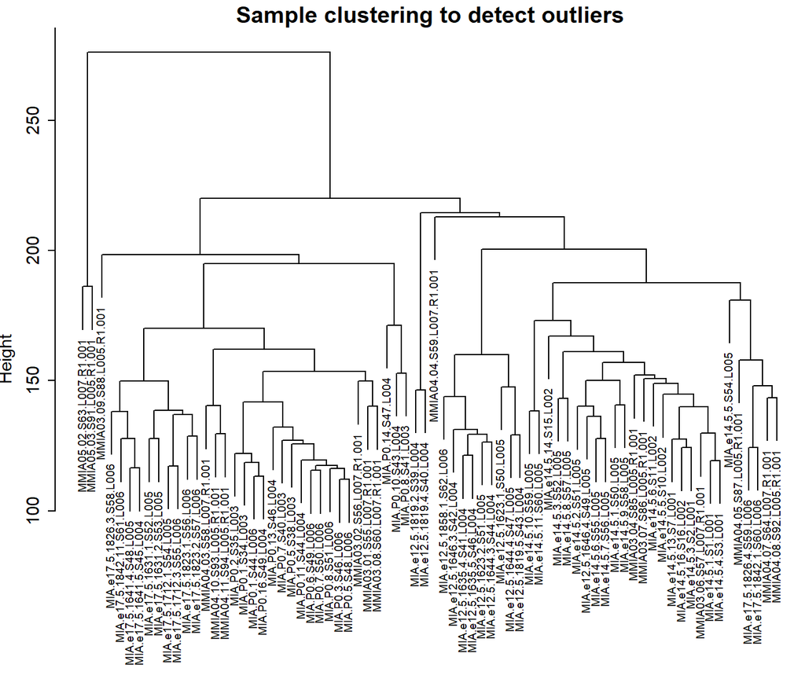

No outlier samples have been detected.

```r
sampleTree = hclust(dist(t(datExpr)), method = "average");

# Plot the sample tree: Open a graphic output window of size 12 by 9 inches
# The user should change the dimensions if the window is too large or too small.

#sizeGrWindow(12,9)
#pdf(file = "Plots/sampleClustering.pdf", width = 12, height = 9);
par(cex = 0.6);
par(mar = c(0,4,2,0))
plot(sampleTree, main = "Sample clustering to detect outliers", sub="", xlab="", cex.lab = 1.5,
     cex.axis = 1.5, cex.main = 2)
```

```r
# Trim the samples if necessary using the cutreeStatic (in the beginning of the tutorial).
# Trimming was not necessary for this dataset
```

## 1.2 Sample dendrogram and trait heatmap

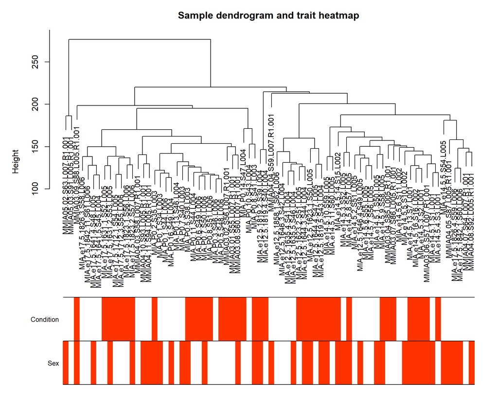

Sample dendrogram and trait heatmap. Red color indicates polyI:C treatment or males.

```r
 # compare samples to traits
 sampleTree2 = hclust(dist(t(datExpr)), method = "average")
 metData2 = metData[,c("Sample_ID", "DPC", "Condition", "Response", "sex.by.rna", "Lane", "Litter")]
 rownames(metData2) = metData2$Sample_ID
 metData2$Sample_ID = NULL

 # Re-cluster samples
 sampleTree2 = hclust(dist(t(datExpr)), method = "average")

 # Convert traits to a color representation: white means low, red means high, grey means missing entry
 m_col <- data.frame("Condition" = as.numeric(ifelse(metData2$Condition=="Saline", 0,1)),
                     "Sex" = as.numeric(ifelse(metData2$sex.by.rna=="M", 1,0)))

 traitColors = numbers2colors(m_col, signed = T)
 colnames(traitColors) <- c("Condition", "Sex")

 par(cex = 0.6);
 par(mar = c(0,4,2,0))
 # Plot the sample dendrogram and the colors underneath.
 plotDendroAndColors(sampleTree2, traitColors,
                      groupLabels = metData2$Sample_ID,
                      main = "Sample dendrogram and trait heatmap")
```

## 1.3 Estimation of the soft-threshold power

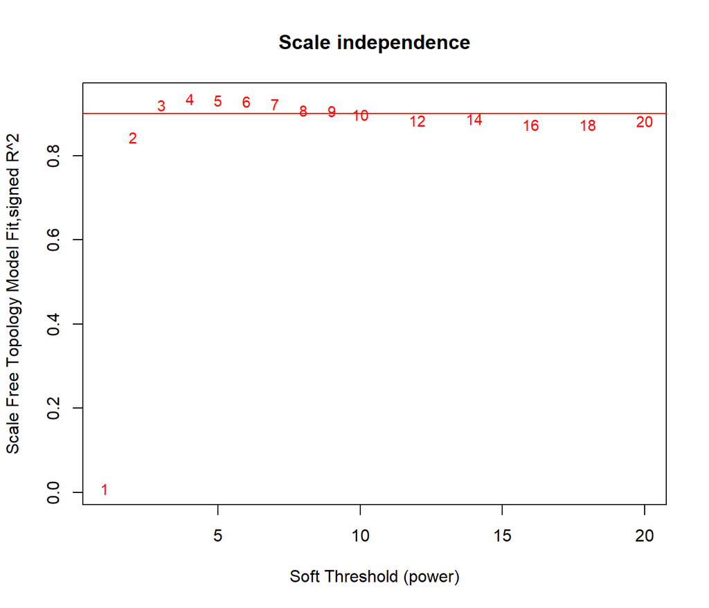

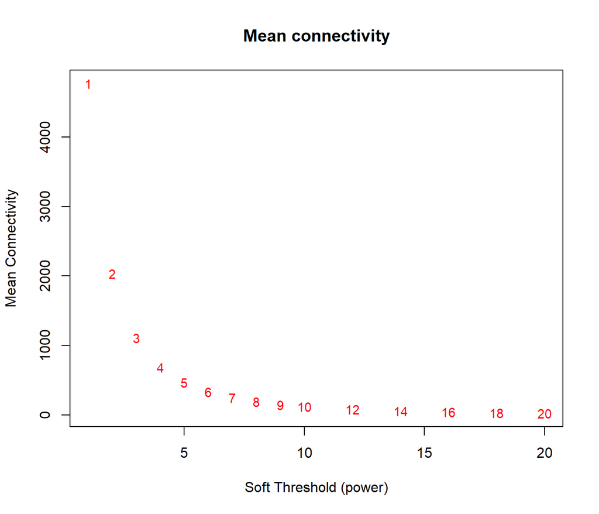

We choose the soft power 3, which is the lowest power at which the scale-free topology reaches high R^2

```r
# Choose a set of soft-thresholding powers
 powers = c(c(1:10), seq(from = 12, to=20, by=2))

# Call the network topology analysis function
# It's conditionally loaded from the file to increase efficiency of writing this report
 if(file.exists("sft.RData")){
  load("sft.RData")
  } else {
  sft = pickSoftThreshold(t(datExpr), powerVector = powers, verbose = 5)
  }

 # Plot the results:
 #sizeGrWindow(9, 5)
 #par(mfrow = c(1,2));
 cex1 = 0.9;

 # Scale-free topology fit index as a function of the soft-thresholding power
 plot(sft$fitIndices[,1], -sign(sft$fitIndices[,3])*sft$fitIndices[,2],
      xlab="Soft Threshold (power)",ylab="Scale Free Topology Model Fit,signed R^2",type="n",
      main = paste("Scale independence"));
      text(sft$fitIndices[,1], -sign(sft$fitIndices[,3])*sft$fitIndices[,2],
      labels=powers,cex=cex1,col="red");
 # this line corresponds to using an R^2 cut-off of h
 abline(h=0.90,col="red")


 # Mean connectivity as a function of the soft-thresholding power
 plot(sft$fitIndices[,1], sft$fitIndices[,5],
      xlab="Soft Threshold (power)",ylab="Mean Connectivity", type="n",
      main = paste("Mean connectivity"))
      text(sft$fitIndices[,1], sft$fitIndices[,5], labels=powers, cex=cex1,col="red")
```

## 1.4 Network construction and module detection

```r
# Automatic network construction and module detection

# Analyzing a dataset with max BlockSize=25000 on a laptop with 16 GB of RAM works just fine,
# but takes a substantial amount of time. ~90 min on Intel(R) Core(TM) i7-5600U CPU.
# From the documentation: "A 16GB workstation should handle up to 20000 probes; a 32GB workstation should handle perhaps 30000."

# I saved the net4.RData object to speed up knitting this report, and decrease carbon footprint.

if(file.exists("net4.RData")){

  load("net4.RData")

  } else {

  # Automatic network construction and module detection
  tmpMulti = as.data.frame(t(datExpr))

  net = blockwiseModules(datExpr=tmpMulti, checkMissingData=TRUE, minModuleSize=10,
                        maxBlockSize=25000,  corType="bicor", power = 3,
                        networkType="signed", TOMType = "signed", saveTOMs=TRUE,
                        saveTOMFileBase=paste("./round1-signed/data/signed-round1"),
                        nThreads=4, verbose=Inf, mergeCutHeight = 0.15,
                        pamStage=FALSE, reassignThreshold=1e-10, deepSplit=2)

  #save(net, file = "net4.RData")

}
```

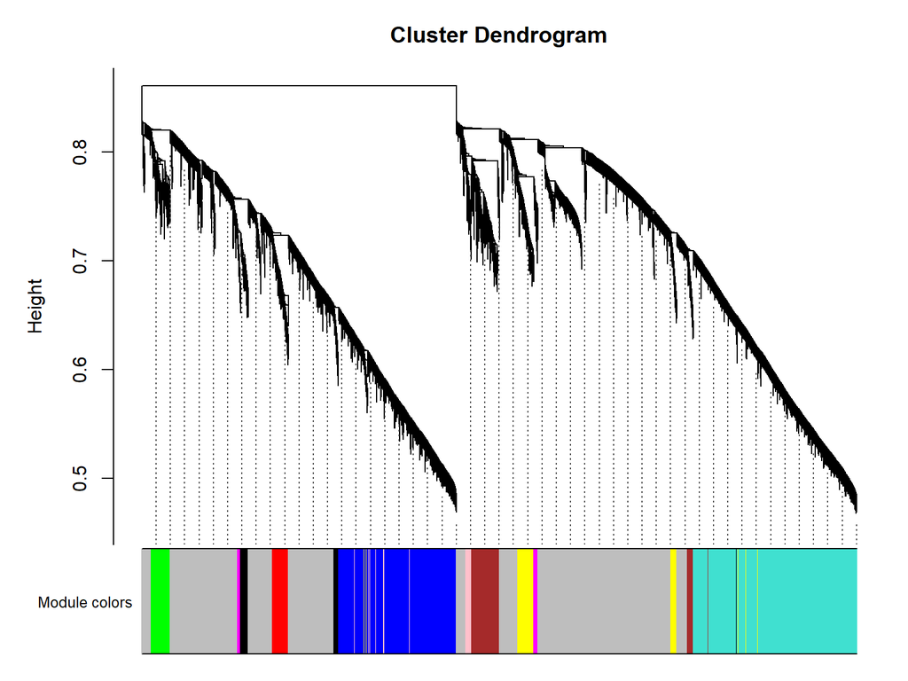

Fig. 2a. WGCNA cluster dendrogram of time series samples identifies genes that were assigned into co-expression modules. Based on similarities in module gene expression, six of the original 10 modules were grouped into two larger modules, BrRePi: Brown, Red and Pink; YeMaBl: Yellow, Magenta and Black.

```r
# Module-trait association testing - full 24015 gene set

 #open a graphics window
 #sizeGrWindow(12, 9)

# Convert labels to colors for plotting
 mergedColors = net$colors
 # Plot the dendrogram and the module colors underneath
 plotDendroAndColors(net$dendrograms[[1]], mergedColors[net$blockGenes[[1]]],
                     "Module colors",
                     dendroLabels = FALSE, hang = 0.03,
                     addGuide = TRUE, guideHang = 0.05)
```

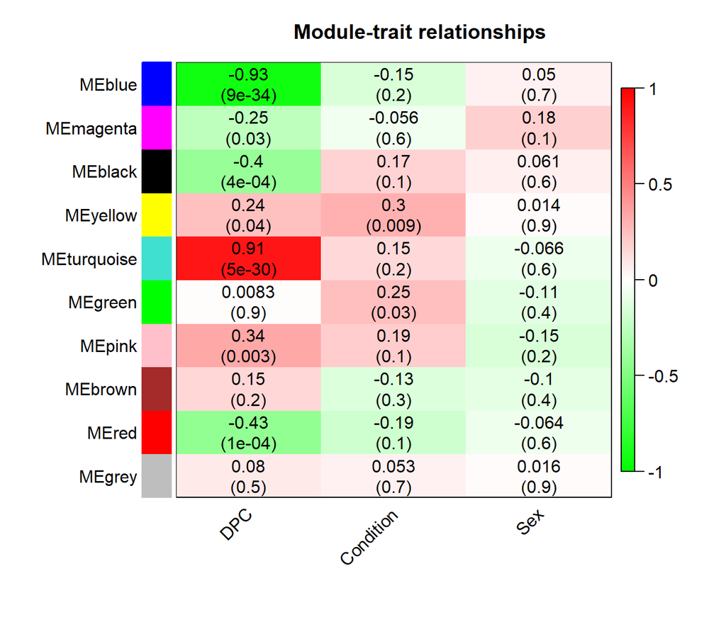

Module-trait association testing. Full 24015 gene set. Numerical values represent signed Pearson’s correlation coefficients, with Student asymptotic p values in brackets. Green represents negative and red represents positive correlation. Color intensity signifies the strength of the correlation.

```r
 moduleLabels = net$colors
 moduleColors = net$colors
 MEs = net$MEs;
 geneTree = net$dendrograms[[1]]


datTraits <- data.frame(DPC=metData$DPC,
                        Condition=ifelse(metData$Condition=="PolyIC", 1, 0),
                        Sex=ifelse(metData$sex.by.rna == "M", 1, 0))

 # Define numbers of genes and samples
 nGenes = ncol(t(datExpr));
 nSamples = nrow(t(datExpr));
 # Recalculate MEs with color labels

 MEs0 = moduleEigengenes(t(datExpr), moduleColors)$eigengenes


 MEs = orderMEs(MEs0)
 moduleTraitCor = cor(MEs, datTraits, use = "p");
 moduleTraitPvalue = corPvalueStudent(moduleTraitCor, nSamples);

 #knitr::kable(moduleTraitPvalue)

 #reading the table. We color code each association by the correlation value:

 #sizeGrWindow(10,6)
 # Will display correlations and their p-values
 textMatrix = paste(signif(moduleTraitCor, 2), "\n(",
                    signif(moduleTraitPvalue, 1), ")", sep = "");
 dim(textMatrix) = dim(moduleTraitCor)
 par(mar = c(6, 8.5, 3, 3));
 # Display the correlation values within a heatmap plot
 labeledHeatmap(Matrix = moduleTraitCor,
                xLabels = names(datTraits),
                yLabels = names(MEs),
                ySymbols = names(MEs),
                colorLabels = FALSE,
                colors = colorRampPalette(c("green", "white", "red"))(1000),
                textMatrix = textMatrix,
                setStdMargins = FALSE,
                cex.text = 1,
                zlim = c(-1,1),
                main = paste("Module-trait relationships"))
```

```r
# We quantify associations of individual genes with our trait of interest  by defining Gene Significance GS as (the absolute value of) the correlation between the gene and the trait. For each module, we also define a quantitative measure of Module Membership (MM) as the correlation of the module eigengene and the gene expression profile. This allows us to quantify the similarity of all genes on the array to every module.
# Define variable weight containing the weight column of datTrait

 modNames = substring(names(MEs), 3)
 geneModuleMembership = as.data.frame(cor(t(datExpr), MEs, use = "p"));
 MMPvalue = as.data.frame(corPvalueStudent(as.matrix(geneModuleMembership), nSamples));

 names(geneModuleMembership) = paste("MM", modNames, sep="");
 names(MMPvalue) = paste("p.MM", modNames, sep="");
 geneTraitSignificance = as.data.frame(cor(t(datExpr), datTraits, use = "p"));

 GSPvalue = as.data.frame(corPvalueStudent(as.matrix(geneTraitSignificance), nSamples));
 names(geneTraitSignificance) = paste("GS.", names(datTraits), sep="");
 names(GSPvalue) = paste("p.GS.", names(datTraits), sep="")

 #head(GSPvalue)
 #moduleTraitPvalue
```

```r
 # merging geneModuleMembership with GSPvalue - gene significance value for the association with a trait.
 geneModuleMembership$gene_name <-rownames(geneModuleMembership)
 GSPvalue$gene_name <- rownames(GSPvalue)
 merged_MM_and_GS <- merge(geneModuleMembership, GSPvalue, by="gene_name")

 geneTraitSignificance$gene_name <- rownames(geneTraitSignificance)
 rownames(geneTraitSignificance) <- NULL
 merged_MM_and_GS <- merge(merged_MM_and_GS, geneTraitSignificance, by="gene_name")

 colors_df <- data.frame(gene_name=rownames(datExpr), moduleColors=moduleColors) # I think the order is correct, but have to verify
 merged_MM_and_GS <- merge(merged_MM_and_GS, colors_df, by="gene_name")

 MMPvalue$gene_name <- rownames(MMPvalue)
 rownames(MMPvalue) <- NULL
 merged_MM_and_GS <- merge(merged_MM_and_GS, MMPvalue, by="gene_name")
```

## 1.5 Merged and filtered modules

```r
# open a graphics window
 #sizeGrWindow(12, 9)
 # Convert labels to colors for plotting
 #mergedColors = net$colors
 # Plot the dendrogram and the module colors underneath
 #plotDendroAndColors(net$dendrograms[[1]], mergedColors[net$blockGenes[[1]]],
 #                     "Module colors",
 #                     dendroLabels = FALSE, hang = 0.03,
 #                    addGuide = TRUE, guideHang = 0.05)

 moduleLabels = net$colors
 moduleColors = net$colors

#I'm editing this script to merge modules containing genes with similar expression trajectory and  function.

 #Brown + Red + Pink = BrRePi, Yellow + Magenta + Black = YeMaBl
 moduleColors_merged= ifelse(moduleColors=="brown", "BrRePi", moduleColors)
 moduleColors_merged= ifelse(moduleColors=="red", "BrRePi", moduleColors_merged)
 moduleColors_merged= ifelse(moduleColors=="pink", "BrRePi", moduleColors_merged)

moduleColors_merged= ifelse(moduleColors=="yellow", "YeMaBl", moduleColors_merged)
moduleColors_merged= ifelse(moduleColors=="magenta", "YeMaBl", moduleColors_merged)
moduleColors_merged= ifelse(moduleColors=="black", "YeMaBl", moduleColors_merged)

moduleLabels= moduleColors_merged
moduleColors = moduleColors_merged


 MEs = net$MEs;
 geneTree = net$dendrograms[[1]];
 #save(MEs, moduleLabels, moduleColors, geneTree,
 #      file = "MIA_Karol_preliminary_-networkConstruction-auto.RData")
```

```r
#I'm filtering the same 17195 genes as used in the DE analysis

datExpr <- rnaData #rnaData contains log2 rpkm values of 74 samples and 24015 genes used for DE expression analysis
datExpr <- as.data.frame(datExpr)
datExpr$moduleColors_merged <- moduleColors_merged
datExpr$moduleColors <- net$colors

datExpr$gene_name <- rownames(datExpr)

original_exp.data <- read.csv(paste0(extsub_dir,"/", "Count_gene_set_from_initial_submission.csv"))

y <- filter(datExpr, gene_name %in% original_exp.data$gene_name)

moduleColors_merged <- y$moduleColors_merged
moduleColors <- y$moduleColors

rownames(y) <- y$gene_name
y$gene_name <- NULL
y$moduleColors_merged <- NULL
y$moduleColors <- NULL

datExpr <- y
```

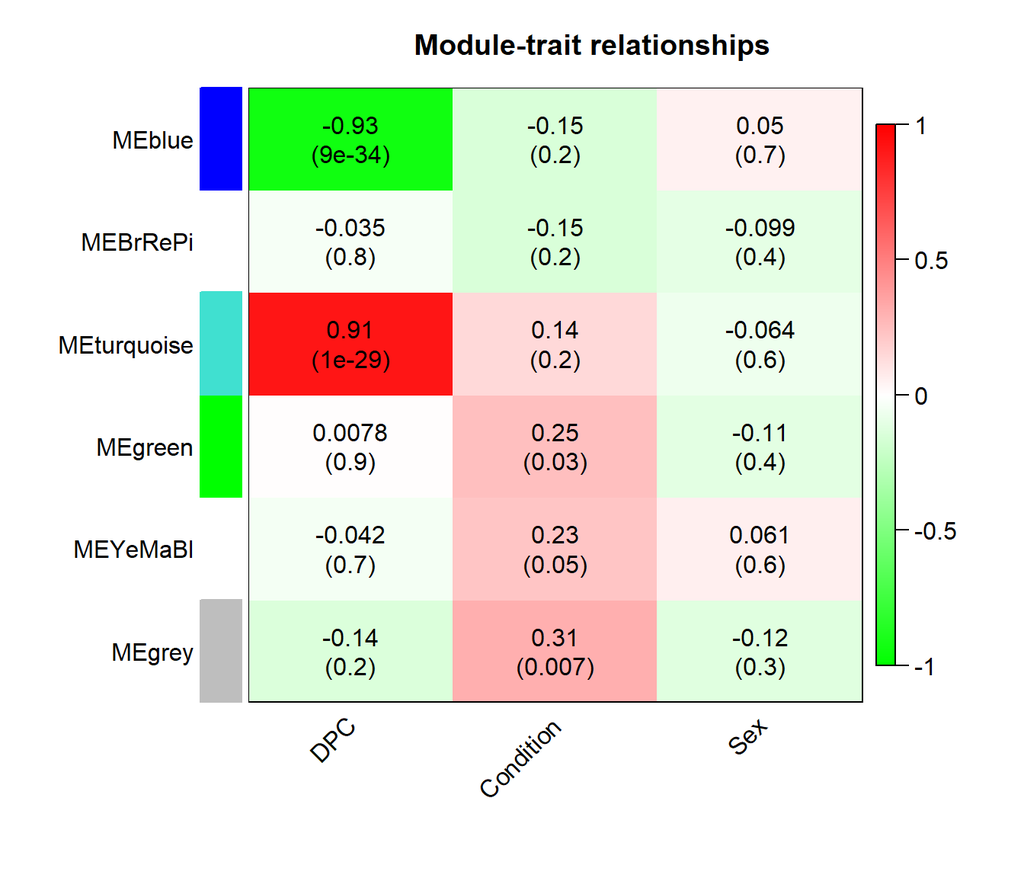

Fig. 2b Heatmap of correlation between gene expression modules and experimental traits; age, condition (saline vs poly(I:C)), and sex. Filtered 17195 gene set. Blue and Turquoise modules are strongly associated with age; Green and Grey modules are significantly associated with MIA condition. Numerical values represent signed Pearson’s correlation coefficients, with Student asymptotic p values in brackets. Green represents negative and red represents positive correlation. Color intensity signifies the strength of the correlation.

```r
datTraits <- data.frame(DPC=metData$DPC,
                        Condition=ifelse(metData$Condition=="PolyIC", 1, 0),
                        Sex=ifelse(metData$sex.by.rna == "M", 1, 0))

 # Define numbers of genes and samples
 nGenes = ncol(t(datExpr));
 nSamples = nrow(t(datExpr));
 # Recalculate MEs with color labels
 MEs0 = moduleEigengenes(t(datExpr), moduleColors_merged)$eigengenes
 MEs = orderMEs(MEs0)
 moduleTraitCor = cor(MEs, datTraits, use = "p");
 moduleTraitPvalue = corPvalueStudent(moduleTraitCor, nSamples);

 #knitr::kable(moduleTraitPvalue)


 #reading the table. We color code each association by the correlation value:

 #sizeGrWindow(10,6)
 # Will display correlations and their p-values
 textMatrix = paste(signif(moduleTraitCor, 2), "\n(",
                    signif(moduleTraitPvalue, 1), ")", sep = "");
 dim(textMatrix) = dim(moduleTraitCor)
 par(mar = c(6, 8.5, 3, 3));
 # Display the correlation values within a heatmap plot
 labeledHeatmap(Matrix = moduleTraitCor,
                xLabels = names(datTraits),
                yLabels = names(MEs),
                ySymbols = names(MEs),
                colorLabels = FALSE,
                colors = colorRampPalette(c("green", "white", "red"))(1000),
                textMatrix = textMatrix,
                setStdMargins = FALSE,
                cex.text = 1,
                zlim = c(-1,1),
                main = paste("Module-trait relationships"))
```

## 1.6 Module trajectories

### 1.6.1 Pre-merged 10 modules

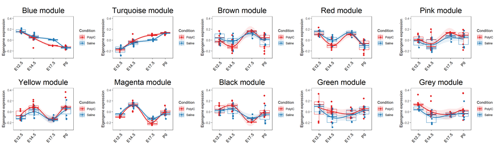

```r
#A proper box plot
#####
#With 10 modules for the supplement

ME_average_exp = moduleEigengenes(t(datExpr), moduleColors)$eigengenes

ME_df <- data.frame(ME_average_exp, "Condition" = metData$Condition, "DPC" = metData$DPC, "ExperimentalDesign" = metData$ExperimentalDesign)


## Eigengenes
Eigengene_module_expression <- function(x){
df <- dplyr::select(ME_df, paste0("ME", x), "Condition", "DPC", "ExperimentalDesign")

j_brew_colors <- brewer.pal(n = 8, name = "Paired")[c(6,2)]

ggplot(df, mapping = aes(x = DPC, y=get(colnames(df)[1]),  colour=Condition))+
  geom_point(size=2, aes(group=ExperimentalDesign), position=position_dodge(width=0.3))+
  geom_boxplot(alpha=0, aes(group=ExperimentalDesign), position="identity")+
  theme_bw()+
  geom_smooth(method = "loess", se=T, aes(fill=Condition,  group=Condition), size  = 1, alpha=0.1)+
  theme(axis.text.x=element_text(angle=50, vjust=0.9, hjust=1, size=12, face="bold"))+
  labs(title= paste(capitalize(x), "module"), x="", y="Eigengene expression")+
  theme(plot.title = element_text(size = rel(2), hjust=0.5))+
  scale_color_manual(values = j_brew_colors)+
  scale_fill_manual(values = j_brew_colors)+
  scale_x_continuous(breaks =c(12.5, 14.5, 17.5, 19.5), labels = c("E12.5", "E14.5", "E17.5", "P0"))+
  coord_cartesian(ylim=c(-0.3, 0.4))+
   theme(#legend.position = "none",
        panel.grid.major = element_blank(),
        panel.grid.minor = element_blank())
}


pl <- lapply(c("blue", "turquoise", "brown", "red", "pink", "yellow", "magenta", "black", "green",  "grey"), function(x)
        Eigengene_module_expression(x))


ml <- marrangeGrob(pl, nrow=2, ncol=5, top = "", layout_matrix = rbind(c(1:5), c(6:10)))
ml
```

### 1.6.2 Merged 6 modules

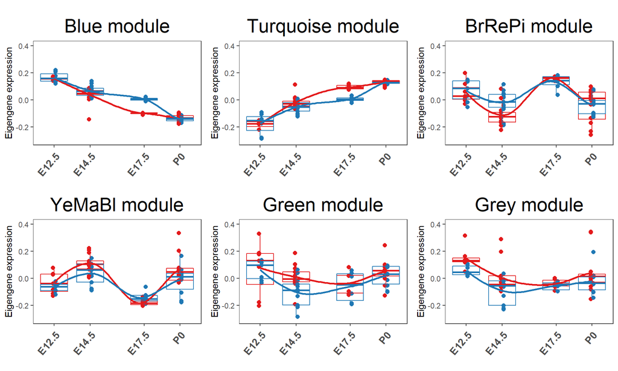

Fig. 2c Module eigengene expression for MIA (red) and control (blue) groups plotted by time-point illustrates expression trajectories across developmental stages, capturing module- and stage-specific differences between MIA and control groups.

```r
##### 6 module trajectories ######
ME_average_exp = moduleEigengenes(t(datExpr), moduleColors_merged)$eigengenes

ME_df <- data.frame(ME_average_exp, "Condition" = metData$Condition, "DPC" = metData$DPC, "ExperimentalDesign" = metData$ExperimentalDesign)

## Eigengenes
Eigengene_module_expression <- function(x){
df <- dplyr::select(ME_df, paste0("ME", x), "Condition", "DPC", "ExperimentalDesign")

j_brew_colors <- brewer.pal(n = 8, name = "Paired")[c(6,2)]

ggplot(df, mapping = aes(x = DPC, y=get(colnames(df)[1]),  colour=Condition))+
  geom_point(size=2, aes(group=ExperimentalDesign), position=position_dodge(width=0.3))+
  geom_boxplot(alpha=0, aes(group=ExperimentalDesign), position="identity")+
  theme_bw()+
  geom_smooth(method = "loess", se=T, aes(fill=Condition,  group=Condition), size  = 1, alpha=0)+
  theme(axis.text.x=element_text(angle=50, vjust=0.9, hjust=1, size=12, face="bold"))+
  labs(title= paste(capitalize(x), "module"), x="", y="Eigengene expression")+
  theme(plot.title = element_text(size = rel(2), hjust=0.5))+
  scale_color_manual(values = j_brew_colors)+
  scale_fill_manual(values = j_brew_colors)+
   coord_cartesian(ylim=c(-0.3, 0.4))+
  scale_x_continuous(breaks =c(12.5, 14.5, 17.5, 19.5), labels = c("E12.5", "E14.5", "E17.5", "P0"))+
  theme(legend.position = "none",
        panel.grid.major = element_blank(),
        panel.grid.minor = element_blank())
}


pl <- lapply(c("blue", "turquoise", "BrRePi", "YeMaBl", "green",  "grey"), function(x)
        Eigengene_module_expression(x))


ml <- marrangeGrob(pl, nrow=2, ncol=3, top = "", layout_matrix = rbind(c(1:3), c(4:6)))
ml
```

```r
#save.image("G:/Shared drives/Nord Lab - Computational #Projects/MIA/Canales_eLIFE_2021_WGCNA_GO/Workspace_3_12_2021.RData")

#load("G:/Shared drives/Nord Lab - Computational #Projects/MIA/Canales_eLIFE_2021_WGCNA_GO/Workspace_3_12_2021.RData")
```

## 1.7 Green and Grey module gene expression

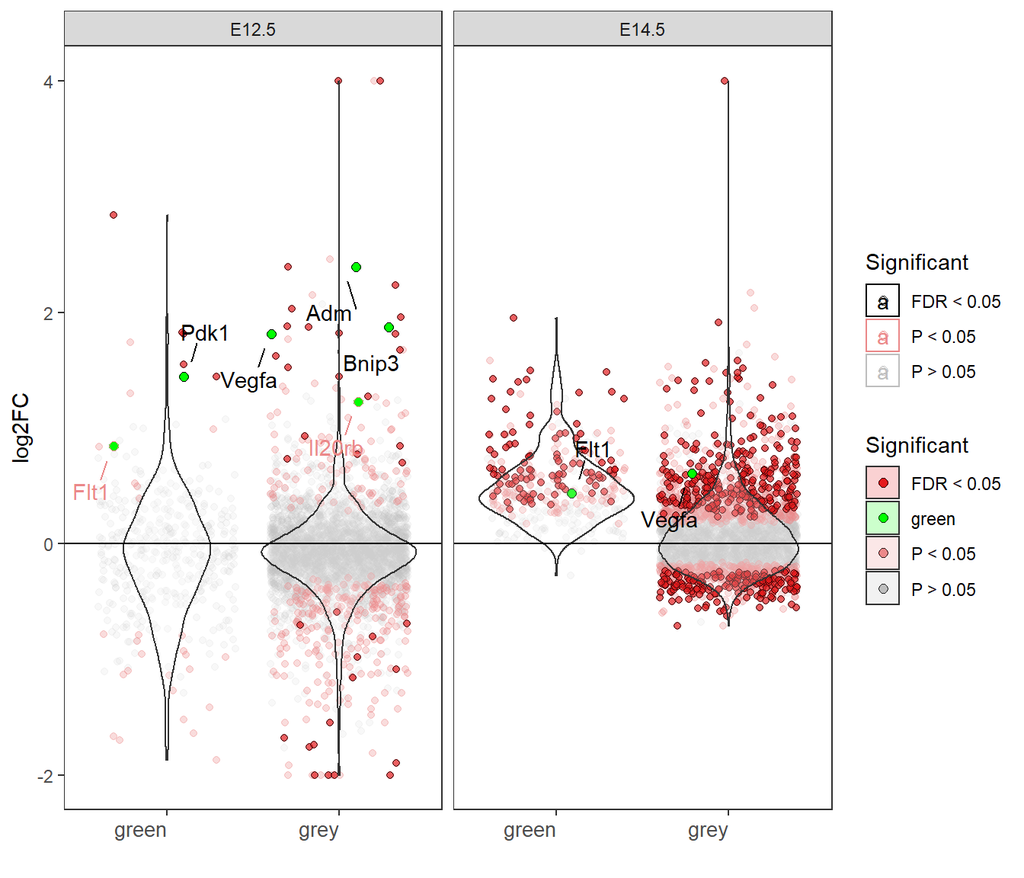

```r
# NOTE: The green color marking was only used to aid with identifying points for precise labeling in the Illustrator

#Filters the original merged_MM_and_GS object. Needed for counting genes in each module.
merged_MM_and_GS_filtered <- filter(merged_MM_and_GS, gene_name %in% rownames(datExpr))
merged_MM_and_GS_filtered$moduleColors_merged <- moduleColors_merged # Yes, I checked the order.

# Reading DE supplementary files
# [,2:7] skips the already present module color assignment columns
E12.5_GLM <- read.csv("Supplementary Table 1 , E12.5_DE_saline_vs_polyIC.csv")[,2:7]
E14.5_GLM <- read.csv("Supplementary Table 2, E14.5_DE_saline_vs_polyIC.csv")[,2:7]
E17.5_GLM <- read.csv("Supplementary Table 3, E17.5_DE_saline_vs_polyIC.csv")[,2:7]
E19.5_GLM <- read.csv("Supplementary Table 4, P0_DE_saline_vs_polyIC.csv")[,2:7]

E12.5_GLM_module <- merge(E12.5_GLM, merged_MM_and_GS_filtered[,c(1,18, 29)], by="gene_name")
E14.5_GLM_module <- merge(E14.5_GLM, merged_MM_and_GS_filtered[,c(1,18, 29)], by="gene_name")
E17.5_GLM_module <- merge(E17.5_GLM, merged_MM_and_GS_filtered[,c(1,18, 29)], by="gene_name")
E19.5_GLM_module <- merge(E19.5_GLM, merged_MM_and_GS_filtered[,c(1,18, 29)], by="gene_name")


E12.5_GLM_module$DPC <- rep("E12.5", nrow(E12.5_GLM_module))
E14.5_GLM_module$DPC <- rep("E14.5", nrow(E14.5_GLM_module))
E17.5_GLM_module$DPC <- rep("E17.5", nrow(E17.5_GLM_module))
E19.5_GLM_module$DPC <- rep("E19.5", nrow(E19.5_GLM_module))


all_GLM_module <- rbind(E12.5_GLM_module, E14.5_GLM_module, E17.5_GLM_module, E19.5_GLM_module)

all_GLM_module$Significant <- ifelse(all_GLM_module$PValue < 0.05, "P < 0.05", "P > 0.05")
all_GLM_module$Significant <- ifelse(all_GLM_module$FDR < 0.05, "FDR < 0.05", all_GLM_module$Significant)


all_GLM_module$moduleColors_merged <- factor(all_GLM_module$moduleColors_merged, levels = c("blue", "turquoise", "BrRePi", "YeMaBl", "grey", "green"))

all_GLM_module <- arrange(all_GLM_module, moduleColors_merged)

all_GLM_module$DPC_module <- paste0(all_GLM_module$DPC, "_", all_GLM_module$moduleColors_merged)

all_GLM_module$moduleColors_merged <- factor(all_GLM_module$moduleColors_merged, levels = c("blue", "turquoise", "BrRePi", "YeMaBl", "green", "grey"))

all_GLM_module <- arrange(all_GLM_module, moduleColors_merged)


#
all_GLM_module <- filter(all_GLM_module, logCPM > 0, DPC %in% c("E12.5", "E14.5"))
all_GLM_module_filtered <- filter(all_GLM_module, moduleColors_merged %in% c("green", "grey"))

#Fig 3a Mol Psych
sel_gene_list <- c("Vegfa", "Flt1", "Adm", "Il20rb", "Bnip3", "Pdk1")

pos <- position_jitter(seed = 1234)
df_mod <- all_GLM_module_filtered
df_mod$logFC <- ifelse(df_mod$logFC > 4, 4, df_mod$logFC)
df_mod$logFC <- ifelse(df_mod$logFC < -2, -2, df_mod$logFC)


p <- ggplot(df_mod,
              aes(x=moduleColors_merged, y=logFC, label=gene_name, color = Significant, fill = Significant))+
  geom_jitter(data=filter(df_mod, Significant == "P > 0.05"),
              aes(fill = Significant), pch=21, alpha=0.1, position = pos)+
  geom_jitter(data=filter(df_mod, Significant == "P < 0.05"),
              aes(fill = Significant), pch=21, alpha=0.3, position = pos)+
  geom_jitter(data=filter(df_mod, Significant == "FDR < 0.05"),
              aes(fill = Significant), pch=21, alpha=0.7, position = pos)+

  geom_point(data=filter(df_mod, logFC > 0, PValue < 0.05, gene_name %in% sel_gene_list),
              aes(x=moduleColors_merged, y=logFC, fill = "green"),
                  pch=21, size=2, alpha=1, position = pos)+

  geom_violin(data=df_mod,
                aes(x=moduleColors_merged, y=logFC, group=DPC_module), alpha=0.2)+
  geom_text_repel(data=filter(df_mod, logFC > 0, PValue < 0.05, gene_name %in% sel_gene_list),
                  point.padding = 1, position = pos)+
  theme_bw()+

  scale_fill_manual(values=c("FDR < 0.05" = "#E41A1C", "P < 0.05"="#eb8889",
                             "P > 0.05" ="grey", "green"="green"))+
  scale_color_manual(values=c("FDR < 0.05" = "black", "P < 0.05"="#eb8889",
                              "P > 0.05" ="grey", "green"="green"))+

  theme(axis.text.x=element_text(vjust=0.9, hjust=1, size=10))+
  labs(x = "", y = "log2FC")+
  facet_wrap(~DPC, ncol = 2)+
  geom_hline(yintercept = 0)+
  theme(panel.grid.major = element_blank(),
        panel.grid.minor = element_blank())

p
```

## 1.8 Module enrichment among DE genes

```r
#Module gene lists
gene_lists <- lapply(c("blue", "turquoise", "BrRePi", "YeMaBl", "green",  "grey"), function(x)
        filter(merged_MM_and_GS_filtered, moduleColors_merged ==x)$gene_name)

blue_genes <- gene_lists[[1]]
turquoise_genes <- gene_lists[[2]]
BrRePi_genes <-  gene_lists[[3]]
YeMaBl_genes <- gene_lists[[4]]
green_genes <- gene_lists[[5]]
grey_genes <-  gene_lists[[6]]
```

```r
#####
#Hypergeometric test split into upregulated and downregulated.

gene_set_enrichment_directional <- function(module_color, DPC){

module <- get(paste0(module_color, "_genes"))
DPC_dataset <- get(paste0(DPC, "_GLM"))

n_of_genes_in_a_module <- length(module)

n_of_DE_Genes_at_a_DPC <- length(filter(DPC_dataset, PValue < 0.05)$gene_name)

n_of_overlapping_DE_genes <- length(intersect(module, filter(DPC_dataset, PValue < 0.05)$gene_name))

fraction_of_overlapping_DE_genes_with_a_module <- n_of_overlapping_DE_genes/n_of_genes_in_a_module

n_of_upregulated_overlapping_genes <- length(intersect(module, filter(DPC_dataset, PValue < 0.05, logFC > 0)$gene_name))
n_of_downregulated_overlapping_genes <- length(intersect(module, filter(DPC_dataset, PValue < 0.05, logFC < 0)$gene_name))

#Anotations on the right refer to the post in the link
  n <- nrow(DPC_dataset)   #Total gene population 15k
  a <- length(module)  #RNA Seq enriched # 3000
  b_up <- length(filter(DPC_dataset, PValue < 0.05 & logFC > 0)$gene_name) #Enriched by Chip-Seq 400
  t_up <- length(intersect(module, filter(DPC_dataset, PValue < 0.05 & logFC > 0)$gene_name)) #Intersected 100
  b_down <- length(filter(DPC_dataset, PValue < 0.05 & logFC < 0)$gene_name)
  t_down <- length(intersect(module, filter(DPC_dataset, PValue < 0.05 & logFC < 0)$gene_name))

  #https://stats.stackexchange.com/questions/16247/calculating-the-probability-of-gene-list-overlap-between-an-rna-seq-and-a-chip-c
#Tests is the number of overlapping genes with a module is enriched comparing to the overall number of genes DE at a DPC.

hypergeometric_test_p_value_upregulated <- sum(dhyper(t_up:b_up, a, n - a, b_up))

hypergeometric_test_p_value_downregulated <- sum(dhyper(t_down:b_down, a, n - a, b_down))

x <- c(n_of_DE_Genes_at_a_DPC, n_of_genes_in_a_module, n_of_overlapping_DE_genes,  fraction_of_overlapping_DE_genes_with_a_module, hypergeometric_test_p_value_upregulated,hypergeometric_test_p_value_downregulated,
  format(n_of_upregulated_overlapping_genes, scientific=FALSE),
  format(n_of_downregulated_overlapping_genes, scientific=FALSE))

x <- as.data.frame(x)
colnames(x) <- "values"
x$module_color <- rep(module_color, 8)
x$DPC <- rep(DPC, 8)
x$stat <- c("n_of_DE_Genes_at_a_DPC", "n_of_genes_in_a_module",  "n_of_overlapping_DE_genes",  "fraction_of_overlapping_DE_genes_with_a_module", "hypergeometric_test_p_value_upregulated", "hypergeometric_test_p_value_downregulated", "n_of_upregulated_overlapping_genes", "n_of_downregulated_overlapping_genes")
x <- x[,c(4,3,2,1)]
#x$values <- format(x$values, scientific=FALSE)
x
}


DPCs <- c("E12.5", "E14.5", "E17.5", "E19.5")
colors <- c("blue", "turquoise", "BrRePi", "YeMaBl", "green",  "grey")

geneset_enrichment_list_directional <- lapply(DPCs, function(y) lapply(colors, function(x) FUN= gene_set_enrichment_directional(x,y)))


#combines the stats for each DPC
E12.5_enrichment_in_modules_dir <- as.data.frame(rbindlist(geneset_enrichment_list_directional[[1]]))
E14.5_enrichment_in_modules_dir <- as.data.frame(rbindlist(geneset_enrichment_list_directional[[2]]))
E17.5_enrichment_in_modules_dir <- as.data.frame(rbindlist(geneset_enrichment_list_directional[[3]]))
E19.5_enrichment_in_modules_dir <- as.data.frame(rbindlist(geneset_enrichment_list_directional[[4]]))



#extracts enrichment p values
E12.5_module_enrichment_p_values_dir <- filter(E12.5_enrichment_in_modules_dir, stat %in% c("hypergeometric_test_p_value_upregulated", "hypergeometric_test_p_value_downregulated"))

E14.5_module_enrichment_p_values_dir <- filter(E14.5_enrichment_in_modules_dir, stat %in% c("hypergeometric_test_p_value_upregulated", "hypergeometric_test_p_value_downregulated"))

E17.5_module_enrichment_p_values_dir <- filter(E17.5_enrichment_in_modules_dir, stat %in% c("hypergeometric_test_p_value_upregulated", "hypergeometric_test_p_value_downregulated"))

E19.5_module_enrichment_p_values_dir <- filter(E19.5_enrichment_in_modules_dir, stat %in% c("hypergeometric_test_p_value_upregulated", "hypergeometric_test_p_value_downregulated"))



# dir stands for direction here...
module_enrich_fun_dir <- function(object, title){
#object <- E17.5_module_enrichment_p_values_dir

object$values <- -log10(as.numeric(as.character(object$value))) + 0.00001 # small addition fixes color assignment issues for value=0

object$DE_dir <- rep(c("up", "down"), 6)

object_up <- filter(object, DE_dir=="up")
object_up$module_color <- factor(object_up$module_color, levels=object_up$module_color)
#Converts Inf value to 25.
object_up$values <- ifelse(object_up$values == "Inf", 300, object_up$values)

#Work zone

object_down <- filter(object, DE_dir=="down")
object_down$module_color <- factor(object_down$module_color, levels=object_down$module_color)
object_down$values <- object_down$values*-1

#Converts -Inf value to -25.
object_down$values <- ifelse(object_down$values == "-Inf", -300, object_down$values)

colors <- rep(c("blue", "turquoise", "brown", "yellow", "green", "grey"), each=2)

ggplot()+
  geom_bar(data = object_up, aes(x=module_color, y= (as.numeric(as.character(values)))), stat = "identity", fill=c("blue", "turquoise", "brown", "yellow", "green", "grey"), color="black")+
geom_bar(data = object_down, aes(x=module_color, y= (as.numeric(as.character(values)))), stat = "identity", fill=c("blue", "turquoise", "brown", "yellow", "green", "grey"), color="black")+
  theme_bw()+
  theme(axis.text.x=element_text(angle=40, vjust=1, hjust=1))+
  labs(x="",y="-log10 (p)", title=title)+
  theme(plot.title=element_text(hjust=0.5))+
  geom_hline(aes(yintercept=-log10(0.05)), colour="#990000", linetype="dashed")+
  geom_hline(aes(yintercept=log10(0.05)), colour="#990000", linetype="dashed")+
  geom_hline(aes(yintercept=0), colour="black", linetype="solid", size=1)
}




E12.5_DE_enrichment_plot_dir <- module_enrich_fun_dir(E12.5_module_enrichment_p_values_dir, "E12.5")+theme(axis.text.x = element_blank())

#E12.5_DE_enrichment_plot_dir


E14.5_DE_enrichment_plot_dir <- module_enrich_fun_dir(E14.5_module_enrichment_p_values_dir, "E14.5")+theme(axis.text.x = element_blank())

E17.5_DE_enrichment_plot_dir <- module_enrich_fun_dir(E17.5_module_enrichment_p_values_dir, "E17.5")+theme(axis.text.x = element_blank())

E19.5_DE_enrichment_plot_dir <- module_enrich_fun_dir(E19.5_module_enrichment_p_values_dir, "P0")

pl <- list(E12.5_DE_enrichment_plot_dir, E14.5_DE_enrichment_plot_dir, E17.5_DE_enrichment_plot_dir, E19.5_DE_enrichment_plot_dir)

#ml <- marrangeGrob(pl, nrow=2, ncol=2, top=textGrob("", gp=gpar(fontsize=12)), bottom="")
#ml

#E12.5_DE_enrichment_plot_dir
#E14.5_DE_enrichment_plot_dir
#E17.5_DE_enrichment_plot_dir
#E19.5_DE_enrichment_plot_dir


### Saving Hypergeometric test for future reference
hyp_geo_p_val_df <- rbind(E12.5_module_enrichment_p_values_dir, E14.5_module_enrichment_p_values_dir,
      E17.5_module_enrichment_p_values_dir, E19.5_module_enrichment_p_values_dir)

hyp_geo_p_val_df$dir <- rep(c("Up", "Down"), 24)

hyp_geo_p_val_df$stat <- NULL

colnames(hyp_geo_p_val_df) <- c("DPC", "module_color", "hypergeometric_test_p_value", "Direction")

hyp_geo_p_val_df <- hyp_geo_p_val_df[,c(1,2,4,3)]

hyp_geo_p_val_df$hypergeometric_test_p_value <- as.numeric(as.character(hyp_geo_p_val_df$hypergeometric_test_p_value))

hyp_geo_p_val_df$Significant <- ifelse(hyp_geo_p_val_df$hypergeometric_test_p_value < 0.05, TRUE, FALSE)

#hyp_geo_p_val_df

#setwd("G:/Shared drives/Nord Lab Team Drive/Manuscripts in preparation/MIA_Canales&Estes/Cell #reports/Reviews/Figures/Misc figures")
#write.csv(hyp_geo_p_val_df, file = "Hypergeometric_P_val_enrichment_Supp_Fig5c.csv")
```

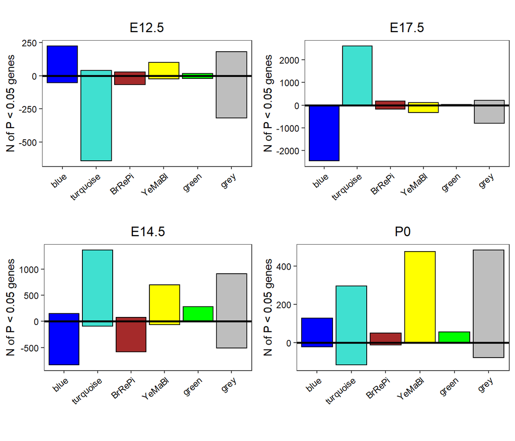

Figure supplement 4. Numbers of DE genes passing P < 0.05 split by modules.

```r
### Numbers of genes ####
E12.5_module_enrichment_ns <- filter(E12.5_enrichment_in_modules_dir, stat %in% c("n_of_DE_Genes_at_a_DPC", "n_of_upregulated_overlapping_genes", "n_of_downregulated_overlapping_genes"))

### Numbers of genes ####
E14.5_module_enrichment_ns <- filter(E14.5_enrichment_in_modules_dir, stat %in% c("n_of_DE_Genes_at_a_DPC", "n_of_upregulated_overlapping_genes", "n_of_downregulated_overlapping_genes"))

### Numbers of genes ####
E17.5_module_enrichment_ns <- filter(E17.5_enrichment_in_modules_dir, stat %in% c("n_of_DE_Genes_at_a_DPC", "n_of_upregulated_overlapping_genes", "n_of_downregulated_overlapping_genes"))

### Numbers of genes ####
E19.5_module_enrichment_ns <- filter(E19.5_enrichment_in_modules_dir, stat %in% c("n_of_DE_Genes_at_a_DPC", "n_of_upregulated_overlapping_genes", "n_of_downregulated_overlapping_genes"))

######
module_enrich_fun_dir_ns <- function(object, title){
#object <- E12.5_module_enrichment_ns

object$values <- as.numeric(as.character(object$value)) + 0.001

#Threshold is the number of DE genes < 0.05 at a particular DPC divided by 12. There are 6 modules, and we are considering enrichment in 2 directions = 12.
threshold <- as.numeric(as.character(object[1,4]))/12

object$DE_dir <- rep(c("_total","_up", "_down"), 6)

object$module_color_dir <- paste0(object$module_color, object$DE_dir)

object <- filter(object, stat %in% c("n_of_upregulated_overlapping_genes", "n_of_downregulated_overlapping_genes"))

object$module_color_dir <- factor(object$module_color_dir, levels=object$module_color_dir)

colors <- rep(c("blue", "turquoise", "brown", "yellow", "green", "grey"))

object_up <- filter(object, DE_dir=="_up")
object_up$module_color <- factor(object_up$module_color, levels=object_up$module_color)

object_down <- filter(object, DE_dir=="_down")
object_down$module_color <- factor(object_down$module_color, levels=object_down$module_color)

ggplot()+
geom_bar(data = object_up, aes(x=module_color, y= as.numeric(as.character(values))), stat = "identity", fill=colors, color="black")+
geom_bar(data = object_down, aes(x=module_color, y= -as.numeric(as.character(values))), stat = "identity", fill=colors, color="black")+
  theme_bw()+
  theme(axis.text.x=element_text(angle=40, vjust=1, hjust=1))+
  labs(x="",y="N of P < 0.05 genes", title=title)+
  theme(plot.title=element_text(hjust=0.5))+
  #geom_hline(aes(yintercept=threshold), colour="#990000", linetype="dashed")+
  #geom_hline(aes(yintercept=-threshold), colour="#990000", linetype="dashed")+
  geom_hline(aes(yintercept=0), colour="black", linetype="solid", size=1)+
  theme(legend.key = element_blank(),
        panel.grid.major = element_blank(),
        panel.grid.minor = element_blank(),
        axis.text=element_text(colour="black")
        )
}


E12.5_DE_enrichment_plot_ns <- module_enrich_fun_dir_ns(E12.5_module_enrichment_ns, "E12.5")
E14.5_DE_enrichment_plot_ns <- module_enrich_fun_dir_ns(E14.5_module_enrichment_ns, "E14.5")
E17.5_DE_enrichment_plot_ns <- module_enrich_fun_dir_ns(E17.5_module_enrichment_ns, "E17.5")
E19.5_DE_enrichment_plot_ns <- module_enrich_fun_dir_ns(E19.5_module_enrichment_ns, "P0")

pl <- list(E12.5_DE_enrichment_plot_ns, E14.5_DE_enrichment_plot_ns, E17.5_DE_enrichment_plot_ns, E19.5_DE_enrichment_plot_ns)

ml <- marrangeGrob(pl, nrow=2, ncol=2, top=textGrob("", gp=gpar(fontsize=12)), bottom="")
ml
```

```r
# E19.5 represents P0

knitr::kable(hyp_geo_p_val_df)
```

| DPC | module_color | Direction | hypergeometric_test_p_value | Significant |
| --- | --- | --- | --- | --- |
| E12.5 | blue | Up | 0.0000000 | TRUE |
| E12.5 | blue | Down | 1.0000000 | FALSE |
| E12.5 | turquoise | Up | 1.0000000 | FALSE |
| E12.5 | turquoise | Down | 0.0000000 | TRUE |
| E12.5 | BrRePi | Up | 0.9999999 | FALSE |
| E12.5 | BrRePi | Down | 1.0000000 | FALSE |
| E12.5 | YeMaBl | Up | 0.0000000 | TRUE |
| E12.5 | YeMaBl | Down | 1.0000000 | FALSE |
| E12.5 | green | Up | 0.8462219 | FALSE |
| E12.5 | green | Down | 0.9989543 | FALSE |
| E12.5 | grey | Up | 0.9905329 | FALSE |
| E12.5 | grey | Down | 0.9999998 | FALSE |
| E14.5 | blue | Up | 1.0000000 | FALSE |
| E14.5 | blue | Down | 0.0000000 | TRUE |
| E14.5 | turquoise | Up | 0.0000000 | TRUE |
| E14.5 | turquoise | Down | 1.0000000 | FALSE |
| E14.5 | BrRePi | Up | 1.0000000 | FALSE |
| E14.5 | BrRePi | Down | 0.0000000 | TRUE |
| E14.5 | YeMaBl | Up | 0.0000000 | TRUE |
| E14.5 | YeMaBl | Down | 1.0000000 | FALSE |
| E14.5 | green | Up | 0.0000000 | TRUE |
| E14.5 | green | Down | 1.0000000 | FALSE |
| E14.5 | grey | Up | 1.0000000 | FALSE |
| E14.5 | grey | Down | 1.0000000 | FALSE |
| E17.5 | blue | Up | 1.0000000 | FALSE |
| E17.5 | blue | Down | 0.0000000 | TRUE |
| E17.5 | turquoise | Up | 0.0000000 | TRUE |
| E17.5 | turquoise | Down | 1.0000000 | FALSE |
| E17.5 | BrRePi | Up | 1.0000000 | FALSE |
| E17.5 | BrRePi | Down | 1.0000000 | FALSE |
| E17.5 | YeMaBl | Up | 1.0000000 | FALSE |
| E17.5 | YeMaBl | Down | 0.7199469 | FALSE |
| E17.5 | green | Up | 1.0000000 | FALSE |
| E17.5 | green | Down | 1.0000000 | FALSE |
| E17.5 | grey | Up | 1.0000000 | FALSE |
| E17.5 | grey | Down | 1.0000000 | FALSE |
| E19.5 | blue | Up | 1.0000000 | FALSE |
| E19.5 | blue | Down | 0.9999975 | FALSE |
| E19.5 | turquoise | Up | 1.0000000 | FALSE |
| E19.5 | turquoise | Down | 0.0000000 | TRUE |
| E19.5 | BrRePi | Up | 1.0000000 | FALSE |
| E19.5 | BrRePi | Down | 0.9980255 | FALSE |
| E19.5 | YeMaBl | Up | 0.0000000 | TRUE |
| E19.5 | YeMaBl | Down | 1.0000000 | FALSE |
| E19.5 | green | Up | 0.0749699 | FALSE |
| E19.5 | green | Down | 1.0000000 | FALSE |
| E19.5 | grey | Up | 0.9777861 | FALSE |
| E19.5 | grey | Down | 0.5727552 | FALSE |

```r
####
```

# 2 Gene Ontology Enrichment

## 2.1 GO Biol. Proc. enrichment

```r
# Function calculating GO enrichment analysis and pulling out significant genes in each GO category
# This script uses FDR < 0.05 gene DE threshold. P0 timepoint is omited because it doesn't have any FDR < 0.05 genes.

# q is the DE analysis dataset,
# b is "upregulated" or "downregulated",
# c represent the number of non trivial nodes- maximizes the number of GO category output. Value determined empirically from the error algorithm prompt.

library(topGO)

GO_analysis <- function(q, b, c) {

  background.genes <- q$gene_name
  geneUniverse <- background.genes

  if(b=="upregulated"){
  test.genes <- filter(q, FDR < 0.05, logFC > 0)$gene_name
  } else if (b=="downregulated"){
    test.genes <- filter(q, FDR < 0.05, logFC < 0)$gene_name
  } else {
    print("Incorect fold change parameter")
    stop()
  }

  genesOfInterest <- test.genes
  geneList <- factor(as.integer(geneUniverse %in% genesOfInterest))
  names(geneList) <- geneUniverse
  myGOdata <- new("topGOdata", description="My project", ontology="BP", allGenes=geneList,  annot=annFUN.org,    mapping="org.Mm.eg.db", ID = "alias", nodeSize=20)
  print(myGOdata)

resultFisher <- runTest(myGOdata, algorithm = "weight01", statistic = "fisher")
#resultKS <- runTest(myGOdata, algorithm = "classic", statistic = "ks")
#resultKS.elim <- runTest(myGOdata, algorithm = "elim", statistic = "ks")
#classicKS = resultKS, elimKS = resultKS.elim, - add later

allRes <- GenTable(myGOdata, classicFisher = resultFisher, orderBy = "classicFisher", topNodes = c)

#showSigOfNodes(myGOdata, score(resultKS.elim), firstSigNodes = 5, useInfo = 'all')
#nodes_plot <- recordPlot(showSigOfNodes(myGOdata, score(resultKS.elim), firstSigNodes = 5, useInfo = 'all'))

#Building a df of DE genes belonging to top 20 GO BP caegories
DE_genes_in_top_GO_cat <- function(r){
 fisher.go <- allRes[r,1]
 #print(allRes[x,c(1,2)])
 fisher.ann.genes <- genesInTerm(myGOdata, whichGO=fisher.go)
 df <- data.frame(GO.ID = allRes[r,c(1)], Term = allRes[r,c(2)], gene_name=intersect(as.character(fisher.ann.genes[[1]]), q$gene_name))
 df <- filter(df, gene_name %in% test.genes)
 df
}

list(allRes, lapply(1:20, DE_genes_in_top_GO_cat))
}


# Runs GO analysis - this will take a few minutes. It's read from a file to speak up the report generation.
if(file.exists("GO_df_all.RData")){

  load("GO_df_all.RData") } else {

GO_E12.5_up <- GO_analysis(E12.5_GLM, "upregulated", 4440)
GO_E12.5_down <- GO_analysis(E12.5_GLM, "downregulated", 4440)

GO_E14.5_up <- GO_analysis(E14.5_GLM, "upregulated", 4462)
GO_E14.5_down <- GO_analysis(E14.5_GLM, "downregulated", 4462)

GO_E17.5_up <- GO_analysis(E17.5_GLM, "upregulated", 4431)
GO_E17.5_down <- GO_analysis(E17.5_GLM, "downregulated", 4431)

# Constructs a data frame for all 3 time points
GO_E12.5_up_df <- data.frame(GO_E12.5_up[1], DPC=rep("E12.5", nrow(as.data.frame(GO_E12.5_up[1]))),
                             DE_direction=rep("Up", nrow(as.data.frame(GO_E12.5_up[1]))))

GO_E12.5_down_df <- data.frame(GO_E12.5_down[1], DPC=rep("E12.5", nrow(as.data.frame(GO_E12.5_up[1]))),
                             DE_direction=rep("Down", nrow(as.data.frame(GO_E12.5_down[1]))))

GO_E14.5_up_df <- data.frame(GO_E14.5_up[1], DPC=rep("E14.5", nrow(as.data.frame(GO_E14.5_up[1]))),
                             DE_direction=rep("Up", nrow(as.data.frame(GO_E14.5_up[1]))))

GO_E14.5_down_df <- data.frame(GO_E14.5_down[1], DPC=rep("E14.5", nrow(as.data.frame(GO_E14.5_up[1]))),
                             DE_direction=rep("Down", nrow(as.data.frame(GO_E14.5_down[1]))))


GO_E17.5_up_df <- data.frame(GO_E17.5_up[1], DPC=rep("E17.5", nrow(as.data.frame(GO_E17.5_up[1]))),
                             DE_direction=rep("Up", nrow(as.data.frame(GO_E17.5_up[1]))))

GO_E17.5_down_df <- data.frame(GO_E17.5_down[1], DPC=rep("E17.5", nrow(as.data.frame(GO_E17.5_up[1]))),
                             DE_direction=rep("Down", nrow(as.data.frame(GO_E17.5_down[1]))))

#
GO_df_all <- rbind(GO_E12.5_up_df, GO_E12.5_down_df,
      GO_E14.5_up_df, GO_E14.5_down_df,
      GO_E17.5_up_df, GO_E17.5_down_df)

GO_df_all$classicFisher <- as.numeric(GO_df_all$classicFisher)

}


#Calculate enrichment
padding = 5
GO_df_all$Enrichment <- log2((GO_df_all$Significant + padding)/(GO_df_all$Expected + padding))

GO_df_all$GO.ID.Term <- paste(GO_df_all$GO.ID, GO_df_all$Term, sep=".")

#Filters GO terms that meet enrichment criteria
short.terms <- unique(filter(GO_df_all, classicFisher < 0.05, Enrichment > 0)$GO.ID.Term)

GO_df_all_filtered <- filter(GO_df_all, GO.ID.Term %in% short.terms)
GO_df_all_filtered$GO.ID.Term <- factor(GO_df_all_filtered$GO.ID.Term, levels = short.terms)


E12.5_GOs_up <- dplyr::select(filter(GO_df_all_filtered, DPC=="E12.5", DE_direction=="Up"),GO.ID.Term, Enrichment)
E14.5_GOs_up <- dplyr::select(filter(GO_df_all_filtered, DPC=="E14.5", DE_direction=="Up"),GO.ID.Term, Enrichment)
E17.5_GOs_up <- dplyr::select(filter(GO_df_all_filtered, DPC=="E17.5", DE_direction=="Up"),GO.ID.Term, Enrichment)

E12.5_GOs_down <- dplyr::select(filter(GO_df_all_filtered, DPC=="E12.5", DE_direction=="Down"),GO.ID.Term, Enrichment)
E14.5_GOs_down <- dplyr::select(filter(GO_df_all_filtered, DPC=="E14.5", DE_direction=="Down"),GO.ID.Term, Enrichment)
E17.5_GOs_down <- dplyr::select(filter(GO_df_all_filtered, DPC=="E17.5", DE_direction=="Down"),GO.ID.Term, Enrichment)


colnames(E12.5_GOs_up) <- c("GO.ID.Term", "E12.5_up")
colnames(E14.5_GOs_up) <- c("GO.ID.Term", "E14.5_up")
colnames(E17.5_GOs_up) <- c("GO.ID.Term", "E17.5_up")


colnames(E12.5_GOs_down) <- c("GO.ID.Term", "E12.5_down")
colnames(E14.5_GOs_down) <- c("GO.ID.Term", "E14.5_down")
colnames(E17.5_GOs_down) <- c("GO.ID.Term", "E17.5_down")


# Merges upregulated and downregulated enrichment values
a <- merge(E12.5_GOs_up, E14.5_GOs_up, by="GO.ID.Term", all = T)
Upregulated_genes_GO <- merge(a, E17.5_GOs_up, by="GO.ID.Term", all = T)

a <- merge(E12.5_GOs_down, E14.5_GOs_down, by="GO.ID.Term", all = T)
Downregulated_genes_GO <- merge(a, E17.5_GOs_down, by="GO.ID.Term", all = T)



GO_df_assembled <- merge(Downregulated_genes_GO, Upregulated_genes_GO,  by="GO.ID.Term")
GO_df_assembled <- arrange(GO_df_assembled, GO.ID.Term)

rownames(GO_df_assembled) <- GO_df_assembled$GO.ID.Term
GO_df_assembled$GO.ID.Term <- NULL

x <- as.matrix(GO_df_assembled)

x[is.na(x)] <- 0

# A heatmap with 1457 categories = not very informative

#paletteLength <- 100

#myBreaks <- c(seq(min(x), 0, length.out=ceiling(paletteLength/2) + 1),
#              seq(max(x)/paletteLength, max(x), length.out=floor(paletteLength/2)))
#myColor <- colorRampPalette(c("#9E0041", "#FEBE6E", "white","#43abea", "#13008e"))(paletteLength)

#pheatmap(x, clustering_distance_rows="correlation", cluster_rows = T, cluster_cols = F, legend = T, fontsize_row  = 9, color = rev(myColor), breaks = myBreaks)
```

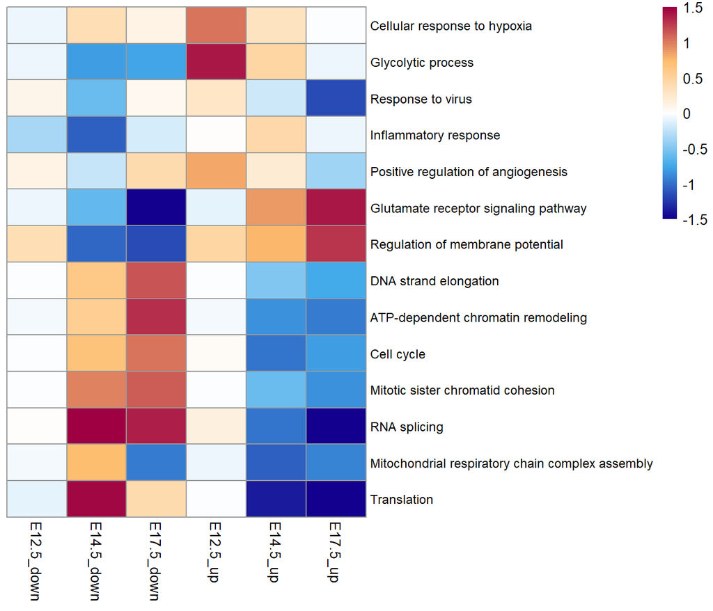

Fig.2d Heatmap of enrichment of DE genes for representative gene ontology biological processes (GO BP) by developmental time-point shows stage- and module-specific transcriptional pathology. Y-axis rows show enrichment for GO BP terms among module-specific DE genes (FDR < 0.05). Heatmap color scale represents relative fold enrichment for the GO terms among DE genes. P0 not shown due to insufficient DE gene numbers and absence of GO BP terms passing enrichment criteria.

```r
# NOTE: Heatmap in Fig. 2d with GO BP categories curated by Karol and Alex. Categories were selected to be representative of WGCNA modules. Heatmaps presented further in this document demonstrate the concordance of this selection with WGCNA GO analysis.

short.terms <- c(

#MIA induced module (Green + Grey)
  "GO:0071456.cellular response to hypoxia",
  "GO:0006096.glycolytic process",
  "GO:0009615.response to virus",
  "GO:0006954.inflammatory response",
  "GO:0045766.positive regulation of angiogenesis",

 #Turquoise
  "GO:0007215.glutamate receptor signaling pathway",
  "GO:0042391.regulation of membrane potential",

  #Blue
  "GO:0022616.DNA strand elongation",
  "GO:0043044.ATP-dependent chromatin remodeling",
  "GO:0007049.cell cycle",

 #YeMaBl
  "GO:0007064.mitotic sister chromatid cohesion",
  "GO:0008380.RNA splicing",

  #BrRePi
  "GO:0033108.mitochondrial respiratory chain complex ...",
  "GO:0006412.translation"
  )

short.terms <- unique(short.terms)

GO_df_all_filtered <- filter(GO_df_all, GO.ID.Term %in% short.terms)

#length(unique(GO_df_all_filtered$GO.ID.Term))

GO_df_all_filtered$GO.ID.Term <- factor(GO_df_all_filtered$GO.ID.Term, levels = short.terms)

E12.5_GOs_up <- dplyr::select(filter(GO_df_all_filtered, DPC=="E12.5", DE_direction=="Up"),GO.ID.Term, Enrichment)
E14.5_GOs_up <- dplyr::select(filter(GO_df_all_filtered, DPC=="E14.5", DE_direction=="Up"),GO.ID.Term, Enrichment)
E17.5_GOs_up <- dplyr::select(filter(GO_df_all_filtered, DPC=="E17.5", DE_direction=="Up"),GO.ID.Term, Enrichment)

E12.5_GOs_down <- dplyr::select(filter(GO_df_all_filtered, DPC=="E12.5", DE_direction=="Down"),GO.ID.Term, Enrichment)
E14.5_GOs_down <- dplyr::select(filter(GO_df_all_filtered, DPC=="E14.5", DE_direction=="Down"),GO.ID.Term, Enrichment)
E17.5_GOs_down <- dplyr::select(filter(GO_df_all_filtered, DPC=="E17.5", DE_direction=="Down"),GO.ID.Term, Enrichment)


colnames(E12.5_GOs_up) <- c("GO.ID.Term", "E12.5_up")
colnames(E14.5_GOs_up) <- c("GO.ID.Term", "E14.5_up")
colnames(E17.5_GOs_up) <- c("GO.ID.Term", "E17.5_up")


colnames(E12.5_GOs_down) <- c("GO.ID.Term", "E12.5_down")
colnames(E14.5_GOs_down) <- c("GO.ID.Term", "E14.5_down")
colnames(E17.5_GOs_down) <- c("GO.ID.Term", "E17.5_down")


a <- merge(E12.5_GOs_up, E14.5_GOs_up, by="GO.ID.Term")
Upregulated_genes_GO <- merge(a, E17.5_GOs_up, by="GO.ID.Term")


a <- merge(E12.5_GOs_down, E14.5_GOs_down, by="GO.ID.Term")
Downregulated_genes_GO <- merge(a, E17.5_GOs_down, by="GO.ID.Term")


GO_df_assembled <- merge(Downregulated_genes_GO, Upregulated_genes_GO,  by="GO.ID.Term")
GO_df_assembled <- arrange(GO_df_assembled, GO.ID.Term)

rownames(GO_df_assembled) <- GO_df_assembled$GO.ID.Term
GO_df_assembled$GO.ID.Term <- NULL

curated_rownames <- c(

#MIA induced module (Green + Grey)
  "Cellular response to hypoxia",
  "Glycolytic process",
  #"Negative regulation of cell proliferation",
  #"Defense response to virus",
  "Response to virus",
  "Inflammatory response",
  "Positive regulation of angiogenesis",

 #Turquoise
  "Glutamate receptor signaling pathway",
  "Regulation of membrane potential",

  #Blue
  "DNA strand elongation",
  "ATP-dependent chromatin remodeling",
  "Cell cycle",

 #YeMaBl
  "Mitotic sister chromatid cohesion",
  "RNA splicing",

  #BrRePi
  "Mitochondrial respiratory chain complex assembly",
  "Translation"
)

#Sanity check = PASSED
# data.frame(rownames(GO_df_assembled), curated_rownames)

rownames(GO_df_assembled) <- curated_rownames

x <- na.omit(as.matrix(GO_df_assembled))

x[is.infinite(x)] <- 0

#Capping the color scale to 1.5
x <- ifelse(x < -1.5, -1.5, x)
x <- ifelse(x > 1.5, 1.5, x)

paletteLength <- 100

myBreaks <- c(seq(min(x), 0, length.out=ceiling(paletteLength/2) + 1),
              seq(max(x)/paletteLength, max(x), length.out=floor(paletteLength/2)))
myColor <- colorRampPalette(c("#9E0041", "#FEBE6E", "white","#43abea", "#13008e"))(paletteLength)

pheatmap(x, clustering_distance_rows="correlation", cluster_rows = F, cluster_cols = F, legend = T, fontsize_row  = 9, color = rev(myColor), breaks = myBreaks)
```